# Math_250_MT1_MN

```r
library(GLMsData)
library(tidyverse)
library(gt)

data(AIS)
```

## Question 1

The dataset `AIS` provides an overview of the body composition of athletes across various sports. Created by the Australian Institute of Sport by Telford and Cunningham in 1991, this dataset includes measurements such as height, weight, and other components related to body composition. Additionally, it contains extensive data on the blood composition of the athletes, including `HCT` (hematocrit), which measures the proportion of red blood cells, and `WBC` (white blood cell count). This indicates that the study was comprehensive in its data collection about these athletes. The primary goal of the study was to investigate whether differences in blood composition correlate with variations in sports careers.

## Question 2

```r
ais_sm <- AIS %>%
  filter(Sport %in% c("BBall",
                      "Rowing",
                      "Field",
                      "TSprnt")) %>%
  select(Sport,
         Sex,
         contains("B")) %>%
  arrange(desc(PBF))

glimpse(ais_sm)
```

```
Rows: 96
Columns: 8
$ Sport <fct> BBall, Rowing, Field, Rowing, Rowing, Rowing, BBall, BBall, Fiel…
$ Sex   <fct> F, F, F, F, F, F, F, F, F, F, F, F, F, F, F, F, F, F, F, F, M, F…
$ LBM   <dbl> 68.53, 54.78, 63.03, 56.48, 60.05, 59.59, 57.18, 48.32, 72.98, 4…
$ BMI   <dbl> 25.75, 22.27, 28.13, 24.21, 24.24, 24.40, 21.88, 22.03, 31.93, 2…
$ RBC   <dbl> 4.71, 3.91, 4.51, 4.49, 4.16, 4.45, 4.11, 4.35, 4.75, 4.42, 4.41…
$ WBC   <dbl> 5.3, 7.3, 9.0, 7.6, 5.8, 6.6, 5.3, 7.8, 7.5, 5.7, 5.9, 6.9, 8.1,…
$ HGB   <dbl> 14.0, 12.9, 14.3, 14.4, 13.3, 14.1, 12.6, 14.1, 15.2, 13.2, 13.5…
$ PBF   <dbl> 28.83, 25.16, 24.88, 24.69, 23.70, 23.70, 23.66, 23.30, 23.01, 2…
```

## Problem 3

```r
prob_3_table <- ais_sm %>%
  slice_head(n = 6) %>%
  gt() %>%
  tab_header(
    title = "The small AIS data set")

prob_3_table
```

The small AIS data set

| Sport | Sex | LBM | BMI | RBC | WBC | HGB | PBF |
| --- | --- | --- | --- | --- | --- | --- | --- |
| BBall | F | 68.53 | 25.75 | 4.71 | 5.3 | 14.0 | 28.83 |
| Rowing | F | 54.78 | 22.27 | 3.91 | 7.3 | 12.9 | 25.16 |
| Field | F | 63.03 | 28.13 | 4.51 | 9.0 | 14.3 | 24.88 |
| Rowing | F | 56.48 | 24.21 | 4.49 | 7.6 | 14.4 | 24.69 |
| Rowing | F | 60.05 | 24.24 | 4.16 | 5.8 | 13.3 | 23.70 |
| Rowing | F | 59.59 | 24.40 | 4.45 | 6.6 | 14.1 | 23.70 |

## Problem 4

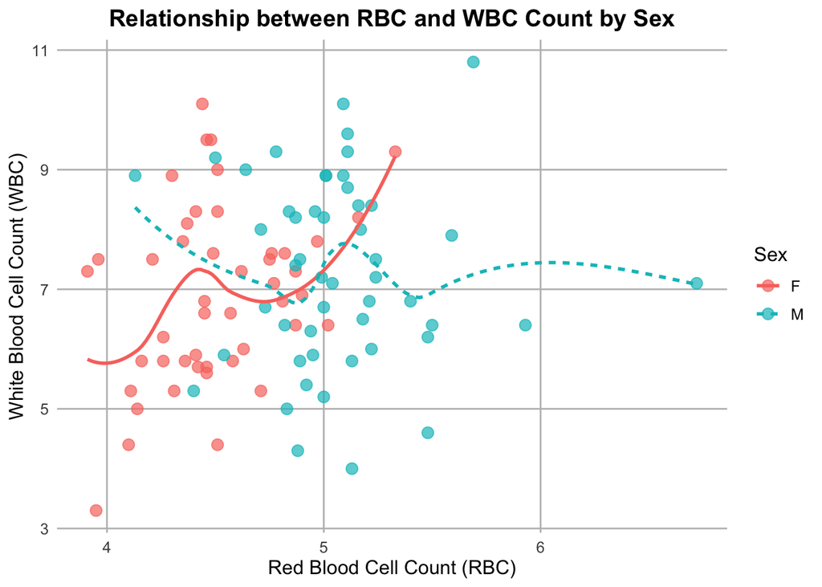

```r
Prob_4_Plot <- ggplot(ais_sm,
        aes(x = RBC,
            y = WBC,
            color = Sex)) +
    geom_point(size = 3,
               alpha = 0.7) +
    geom_smooth(method = "loess",
                se = FALSE,
                aes(linetype = Sex)) +
    scale_fill_brewer(palette = "Dark2") +
    labs(title = "Relationship between RBC and WBC Count by Sex",
        x = "Red Blood Cell Count (RBC)",
        y = "White Blood Cell Count (WBC)",
        color = "Sex") +
    theme_minimal() +
    theme(
      text = element_text(size = 12),
      legend.position = "right",
      plot.title = element_text(hjust = 0.5, face = "bold"),
      panel.grid.major = element_line(size = 0.5, linetype = 'solid', colour = "grey"),
      panel.grid.minor = element_blank())
print(Prob_4_Plot)
```

## Problem 5

```r
wbc_summary <- ais_sm %>%
  group_by(Sex) %>%
  summarize(
    Q1 = quantile(WBC, 0.25),
    Q3 = quantile(WBC, 0.75),
    IQR = Q3 - Q1,
    Lower_Bound = Q1 - 1.5 * IQR,
    Upper_Bound = Q3 + 1.5 * IQR,
    Mean = mean(WBC, na.rm = TRUE),
    SD = sd(WBC, na.rm = TRUE)
  )

print(wbc_summary)
```

```
# A tibble: 2 × 8
  Sex      Q1    Q3   IQR Lower_Bound Upper_Bound  Mean    SD
  <fct> <dbl> <dbl> <dbl>       <dbl>       <dbl> <dbl> <dbl>
1 F      5.8   7.75  1.95        2.87        10.7  6.89  1.48
2 M      6.22  8.4   2.17        2.96        11.7  7.29  1.57
```

## Problem 6

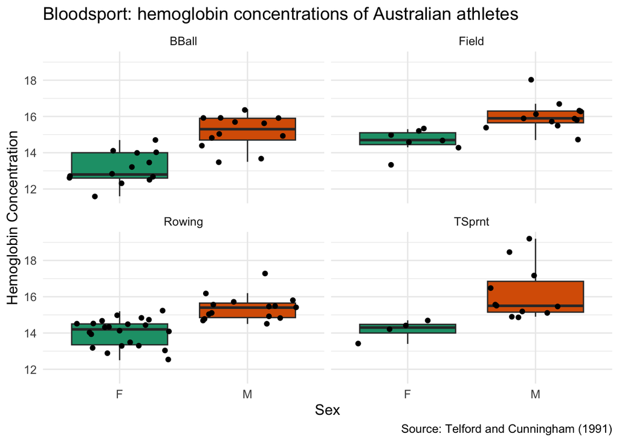

```r
ggplot(ais_sm,
       aes(x = Sex,
           y = HGB,
           fill = Sex)) +
  scale_fill_brewer(palette = "Dark2") +
  geom_boxplot(outlier.shape = NA) +
  geom_jitter() +
  facet_wrap(~ Sport, ncol = 2) +
  labs(title = "Bloodsport: hemoglobin concentrations of Australian athletes",
       x = "Sex",
       y = "Hemoglobin Concentration",
       caption = "Source: Telford and Cunningham (1991)") +
  theme_minimal() +
  theme(
    text = element_text(size = 12),
    legend.position = "none")
```

## Problem 7

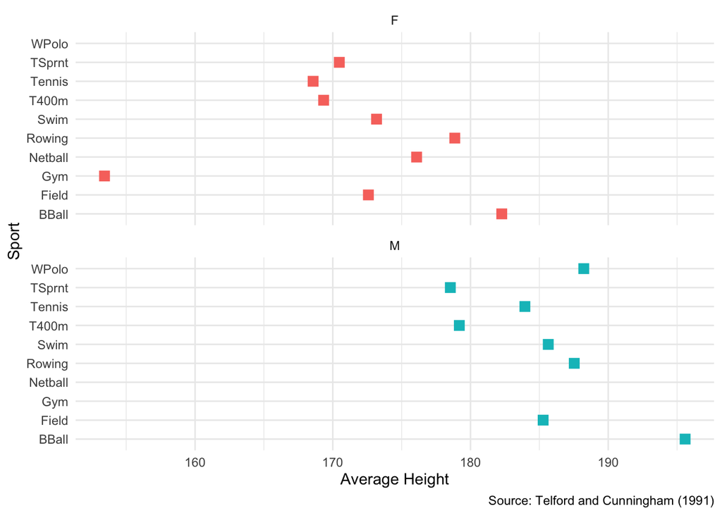

```r
ggplot(AIS, aes(x = Ht,
                y = Sport,
                fill = Sex)) +
  stat_summary(fun = mean,
               geom = "point",
               shape = 22, size = 4,
               stroke = 0,
               position = position_dodge(width = 0.5),
               na.rm = TRUE) +
  labs(x = "Average Height",
       y = "Sport",
       caption = "Source: Telford and Cunningham (1991)") +
  facet_wrap(~ Sex,
             ncol = 1) +
  theme_minimal() +
  theme(legend.position = "none",
        plot.title = element_blank()
  )
```

The default color pallete is distinguishing enough to not have to code in another one.